[figure not shown]

# Calibration Is a Choice

Constrained Bayesian optimization for adaptive clinical trial design, and the frontier hiding behind the word “calibrated”

Naim Rashid

Department of Biostatistics · Lineberger Comprehensive Cancer Center · UNC Chapel Hill

Computational Medicine Seminar · UNC Chapel Hill · September 4, 2026

## This talk exists because of one trial program

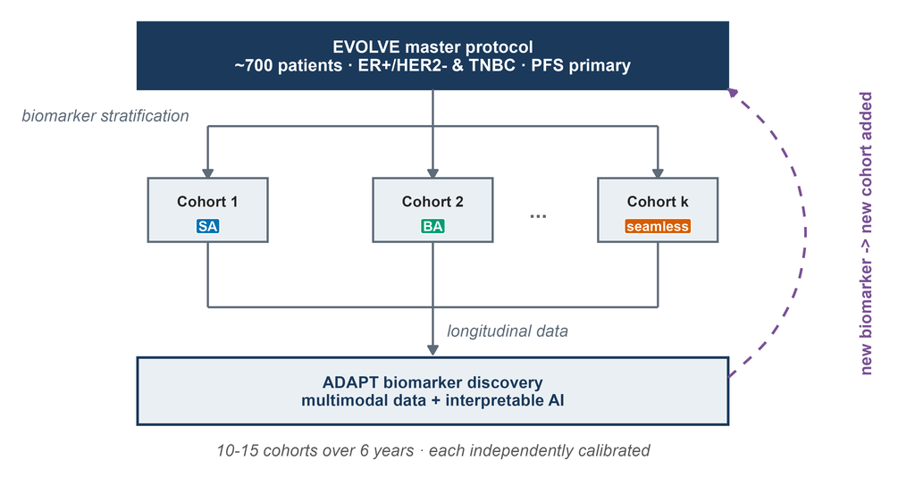

**EVOLVE**, the breast cancer platform trial of the ARPA-H ADAPT program: one master protocol that repeatedly opens biomarker-defined subtrials, **10 to 15 over its life, each needing its own design**. One of those design jobs took two weeks by hand and failed. The same problem later took 45 minutes. This talk is about what changed.

## Two designs. Both correct.

The platform’s triple-negative breast cancer cohort: one arm, judged against a historical control (a survival benchmark from prior studies; there is no concurrent control arm). Two candidate designs, same requirements: **power at least 0.80, type I error at most 0.10**.

|  | Design 1 | Design 2 |
| --- | --- | --- |
| Maximum patients the trial may enroll | **47** | **30** |
| Average patients enrolled *when the drug does not work* | **11.7** | **22.8** |
| Power *(chance of a go when the drug works)* | 0.86 | 0.94 |
| Type I error *(chance of a false go)* | 0.001 | 0.021 |

Both are calibrated. Which one is *the* calibrated design?

## The claim I want you to leave with

Calibrating an adaptive trial does not have one answer. It has a frontier of feasible answers, and nearly every trial picks its point on that frontier without ever seeing the alternatives.

BATON does three things about that:

1. **Finds** feasible designs automatically, in a space where feasibility cannot be written down.
2. **Optimizes** within the feasible set, under an objective you choose deliberately.
3. **Names the choice**, so the trade-off is made by investigators, not by default.

Part 1

Two designs, both correct

What does “calibrated” actually fail to pin down?

## Trials are built around two mistakes

A trial exists to earn one decision, with error guarantees agreed **before patient one enrolls**: does this treatment work well enough to act on?

|  | The drug works | The drug does not work |
| --- | --- | --- |
| **Trial says go** | Correct *(power: chance of this)* | **False go** *(type I error)* |
| **Trial says stop** | **Missed winner** *(type II error)* | Correct |

Regulators cap the false-go rate (0.05 for confirmatory trials; 0.10 for screening trials like ours). Power at least 0.80 is your own insurance against killing a winner.

## For a traditional trial, design means solving one equation for N

You prespecify three things:

1. **The effect size you assume**: how big a benefit you are designing to detect
2. **The type I ceiling**: the false-go rate you will tolerate
3. **The power floor**: the minimum probability of detecting a real effect

A closed-form formula then hands you the fourth: **the minimum sample size N**. Every statistics package solves it in a millisecond.

The knobs move as you would expect: assume a smaller effect, N grows fast; tighten the ceiling or raise the floor, N grows. The assumed effect size is a *guess*, and the whole design conditions on it.

One equation, one unknown. Hold that thought.

## Adaptive means acting on accumulating data, by rules fixed in advance

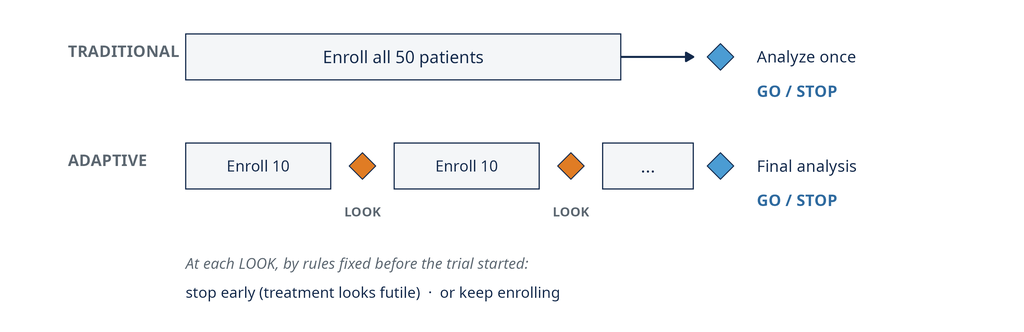

The adaptive version has more knobs, and every knob changes how the trial behaves. (Schematic; our designs check futility at the looks and decide efficacy at the end.)

## A trial design is a point in an 8-dimensional space

An adaptive trial is specified by numbers like:

- **Maximum enrollment**: the most patients it may ever take
- **First interim look**: when we first check the data
- **Stopping thresholds**: how much evidence of failing (futility) or working (efficacy) stops it early
- **Decision margin**: how much better than control counts as “working”

…plus four more: interim spacing, an events gate, prior strength, model resolution. Eight in all.

Change any one, and the trial *behaves differently*.

**“Behaves differently” means:**

- power
- type I error
- expected patients enrolled, under the null and under the alternative
- probability of stopping early

The design is the input. The behavior is the output. The mapping between them is the whole problem.

## The mapping from design to behavior has no formula

For a fixed-sample trial, power is a closed-form calculation. Every biostatistics student does it on a whiteboard.

For an adaptive trial, the design’s behavior depends on **every interim decision interacting with every other**:

- an early futility look changes who survives to the later looks
- the decision margin changes the futility look’s behavior
- enrollment speed changes what data each look sees (survival endpoint: data maturity depends on calendar time, not just patient count)

The only general way to learn how a candidate design behaves is to **simulate the trial thousands of times** and count what happened.

So evaluating *one* point in design space costs thousands of simulated trials.

## Every number in this talk is a tally over thousands of these

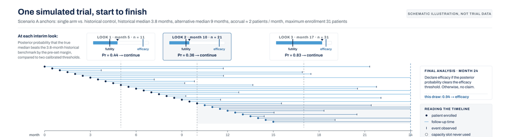

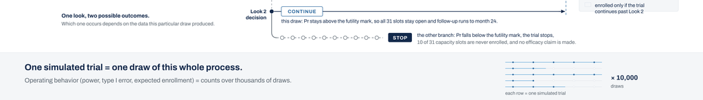

## Count the draws, and you have the opening table

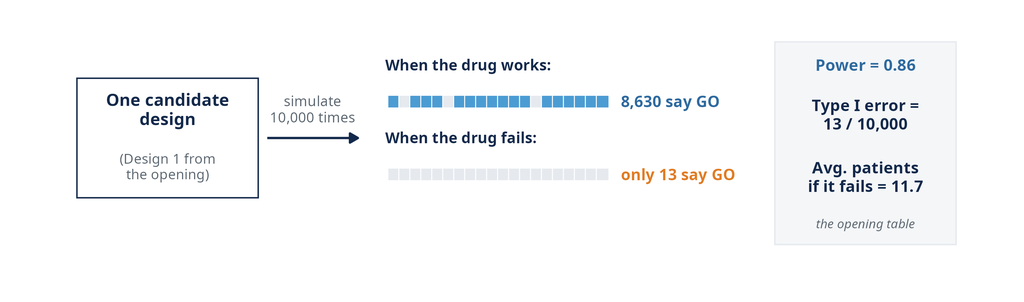

## “Calibrated” means constraints are met. Constraints do not pick a design.

**What regulators and review boards require:**

- Type I error at most a ceiling (0.10 here: a screening-phase bar for go/no-go subtrials, set per trial by its decision context)
- Power at least a floor (here 0.80)

A design meeting these is **feasible**. Calibration, as usually practiced, stops here.

**What the requirements never mention:**

- how many patients the trial risks at maximum
- how many patients it wastes when the drug fails
- how fast it reaches an answer

Feasibility is a *region*, not a point. Everything inside it is “calibrated.”

The cold-open designs are both inside the region. They differ on everything the requirements do not mention.

## Naming points on the frontier: design philosophies

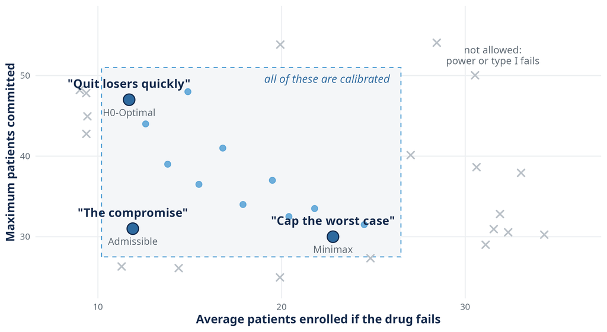

**Quit losers quickly** (H0-Optimal): fewest patients wasted when the drug fails. **Cap the worst case** (Minimax): smallest maximum commitment. **The compromise** (Admissible): a weighted blend. Classical two-stage designs have carried the formal names since the 1980s; BATON extends them to spaces where no table of designs exists.

## What I am not arguing

**Not** that trials are currently miscalibrated. Feasible designs found by hand are feasible. The claim is that the *choice among them* has been invisible.

**Not** that one philosophy is right. H0-Optimal and Minimax encode different, legitimate priorities. The method is deliberately neutral among them.

**Not** that optimization replaces statisticians. It replaces the *grid search* part of their month, not the judgment part.

## Two problems, stacked

**Problem 1: find the acceptable region.**  
Out of thousands of possible designs, which satisfy power at least 0.80 and type I error at most 0.10?

↓

**Problem 2: choose the trade-off within it.**  
Among the acceptable designs, which philosophy do we want to commit to?

Neither problem has a formula. BATON solves both in one search, and Part 2 is how.

Part 2

Searching a space you cannot write down

Why can you not just grid search it?

## The feasible region is a thin, curved sliver

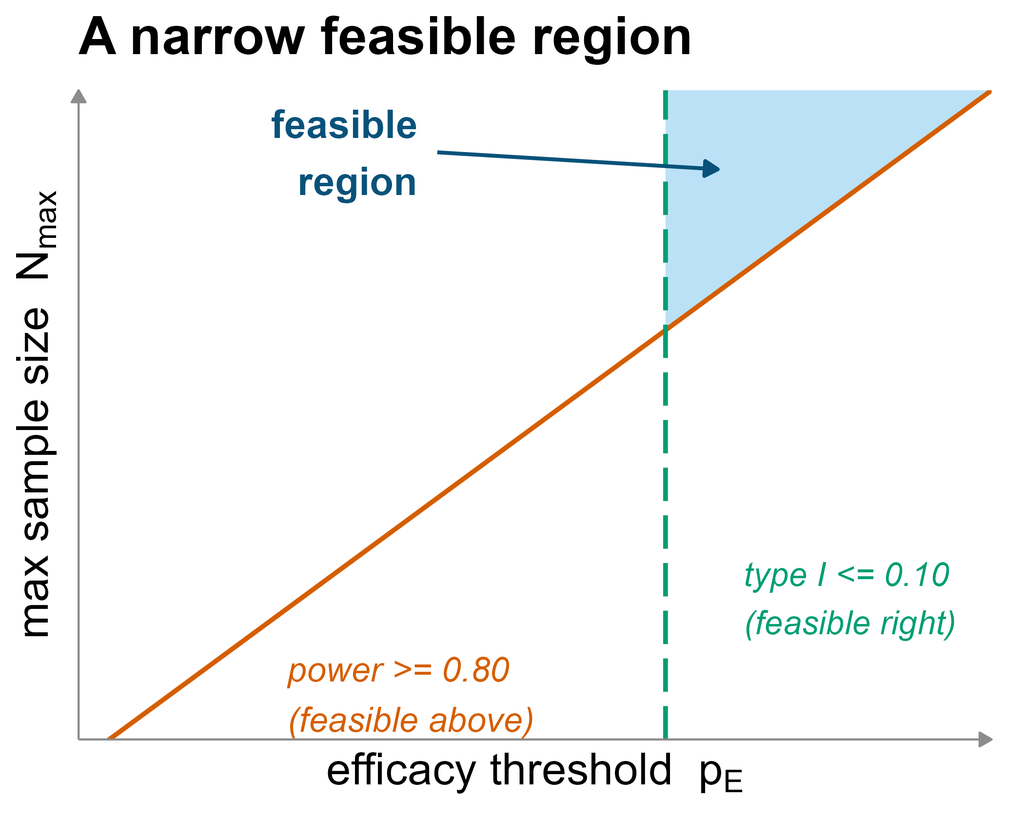

A 2-D cartoon slice of the 8-dimensional space. You cannot write the region down: its boundary is defined by simulation output, estimated with Monte Carlo noise, and it curves through all 8 dimensions at once.

## Random search finds the sliver 7% of the time

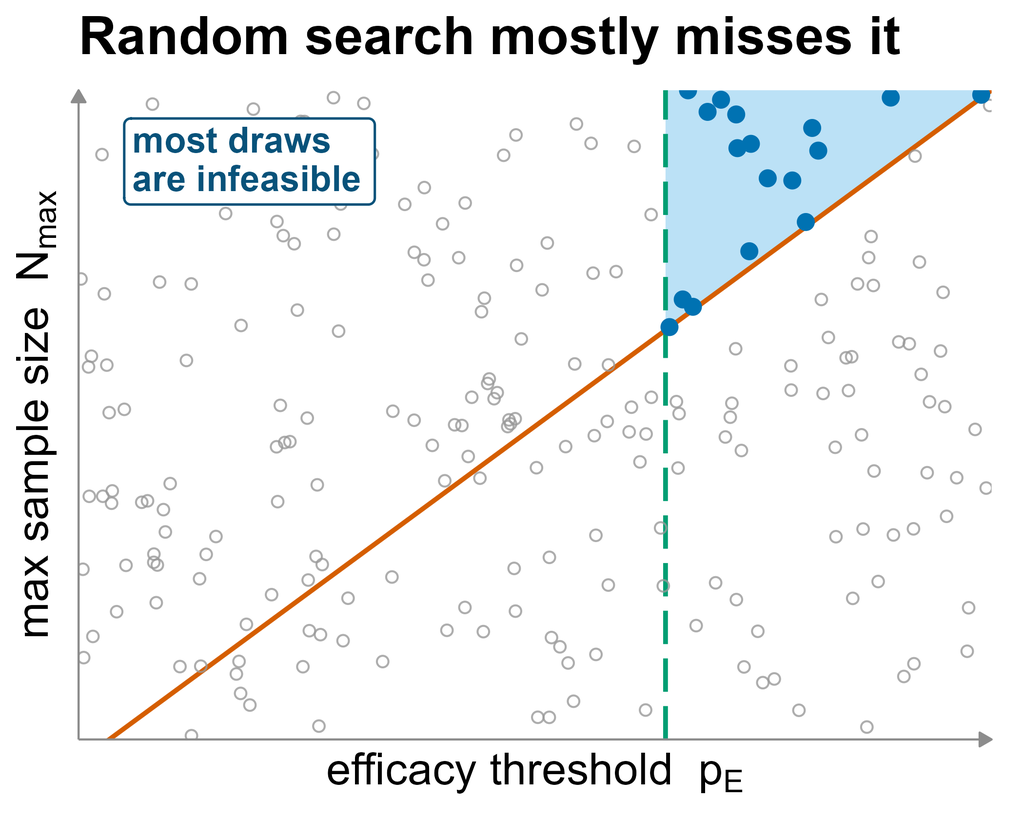

**2,000 random designs, evaluated by simulation:**

| Feasible | **136 / 2,000** |
| --- | --- |
| Feasibility rate | **6.8%** |

93% of the simulation budget is spent learning that a design is infeasible, and the search still cannot tell you it found the frontier. (One scenario, our prespecified search box: an example, not a universal constant.)

## Instead of carpeting the space, the model walks toward the optimum

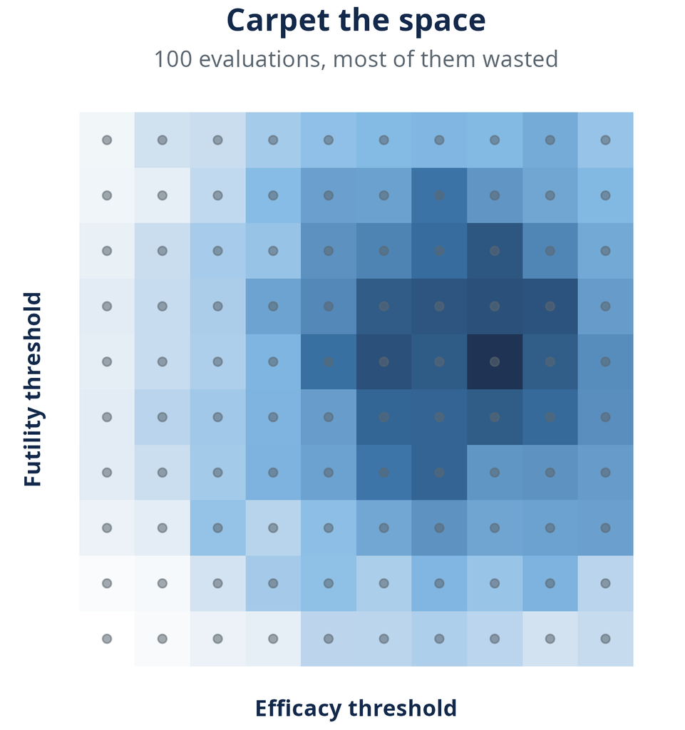

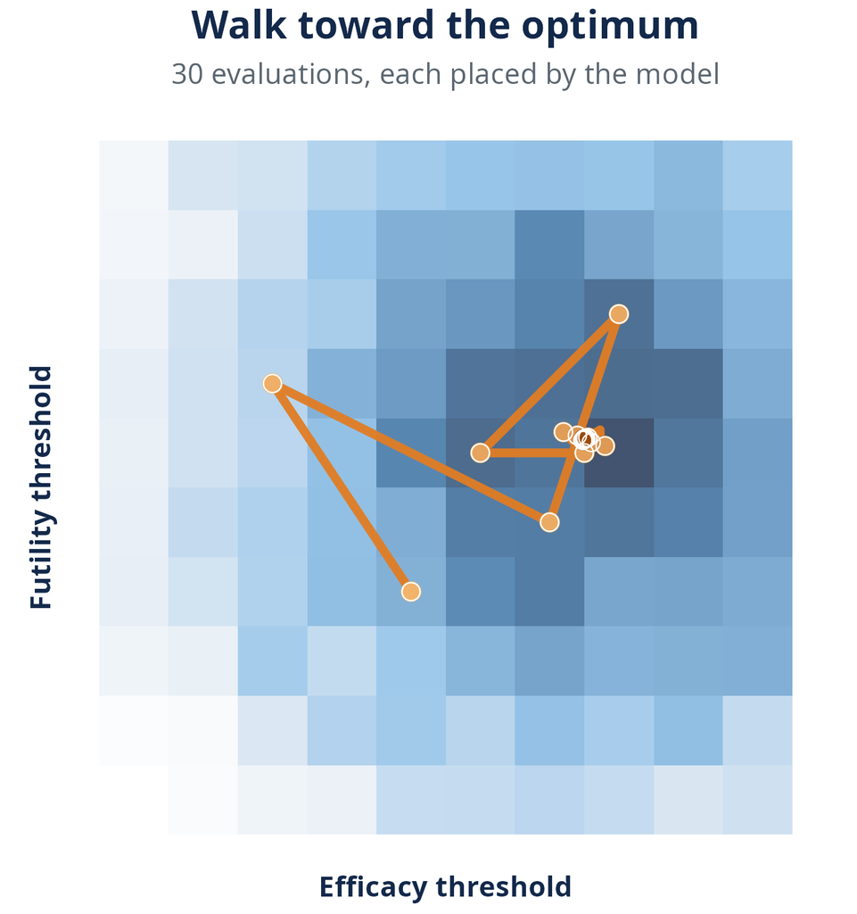

Same surface (darker = better design), both find the optimum. One spends its budget everywhere; the other spends it where the model says the next evaluation is worth the most.

## BATON closes the loop: simulate, model, decide where to look next

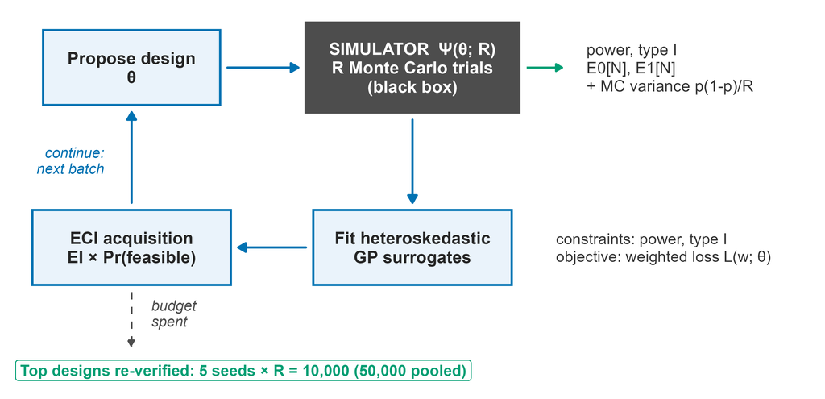

Try a design → simulate what happens → learn from everything tried so far → choose the most useful place to try next. Repeat.

Formal names for those steps: candidate proposal · Monte Carlo simulator · Gaussian-process surrogate (a fast emulator of the simulator) · feasibility-aware acquisition. Active learning, aimed at trial designs.

## Three ingredients, one slide

| Ingredient | What it does | Why it is needed here |
| --- | --- | --- |
| **Surrogate model** | Gaussian process predicts each behavior metric, with uncertainty, from every design simulated so far | Recycles simulations too expensive to waste |
| **Feasibility-aware acquisition** | Next design maximizes expected gain *times* probability of meeting every constraint | Draws the search toward the boundary, where the frontier lives |
| **Multi-fidelity ladder** | Cheap, noisy simulations first; promising candidates earn high-replication runs | Most candidates are bad; discover that cheaply |

These are familiar computational ideas. The novelty is the assembly: constraints as first-class citizens, and the frontier, not a single optimum, as the deliverable.

## The fidelity ladder spends simulation where it matters

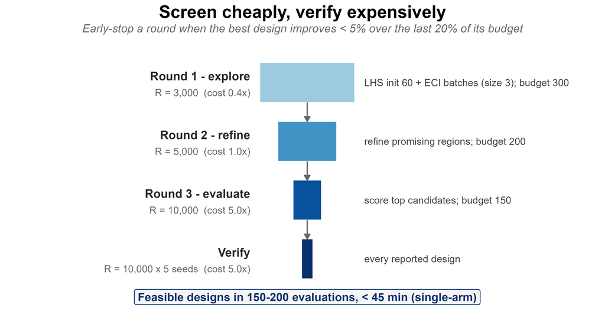

Cheap screening for the many, expensive certainty for the few, and independent re-verification for the one design you report.

## The first 100 evaluations are random search. Then the model takes over.

Benchmark: **Simon two-stage designs**, a classical problem small enough to enumerate every possible design, so the exact optimum is known. A unit test with a known answer.

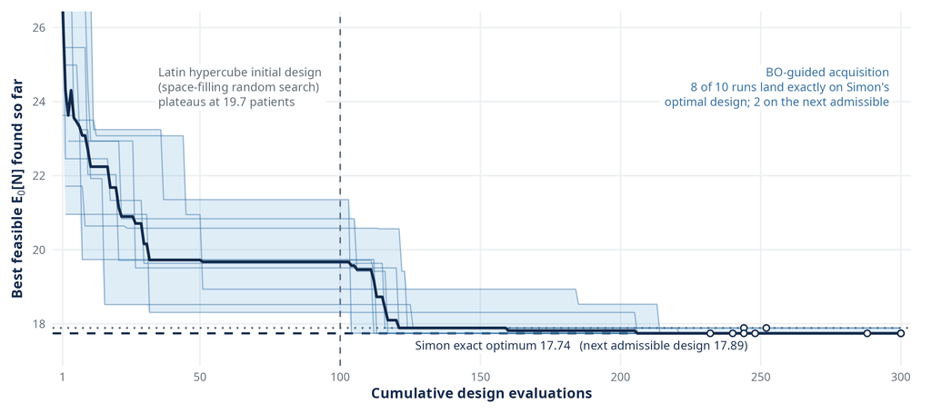

Ten runs on this benchmark. The space-filling phase plateaus at 19.7 patients; the surrogate-guided phase closes the gap, and 8 of 10 runs land on Simon’s exact optimal design.

Part 3

What the frontier looks like

What do you see once you can find the whole frontier?

## Scenario A: the cold open, resolved

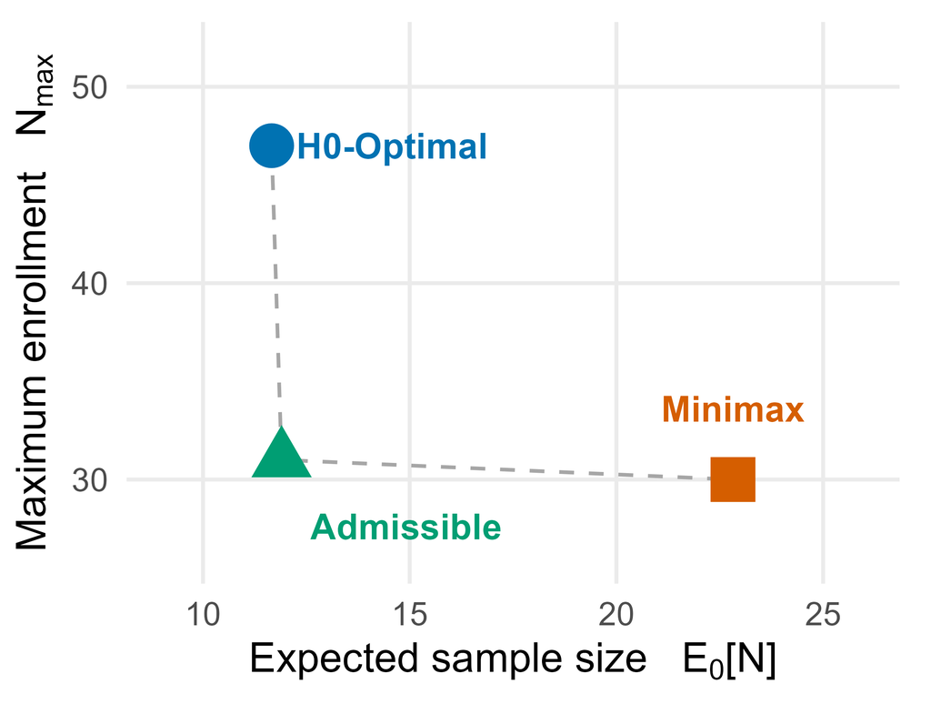

Triple-negative breast cancer, single arm vs. historical control

| Design | Max N | Avg. N if drug fails | Power | Type I |
| --- | --- | --- | --- | --- |
| **H0-Optimal** | 47 | 11.7 | 0.86 | 0.001 |
| **Admissible** | 31 | 11.9 | 0.84 | 0.022 |
| **Minimax** | 30 | 22.8 | 0.94 | 0.021 |

All three clear the same power floor and type I ceiling. Power *varies* because it is a constraint, not the objective.

## The same structure appears in a randomized comparison

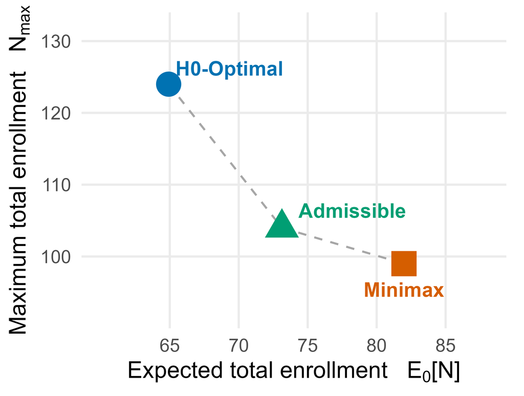

ER-positive cohort, doublet vs. triplet therapy, 1:1 randomization

| Design | Max N | Avg. N if drug fails | Power | Type I |
| --- | --- | --- | --- | --- |
| **H0-Optimal** | 124 | 64.9 | 0.82 | 0.081 |
| **Admissible** | 104 | 73.1 | 0.81 | 0.087 |
| **Minimax** | 99 | 82.0 | 0.81 | 0.094 |

Cutting the worst-case cap from 124 to 104 costs about 8 extra patients on average when the treatment does not help; cutting it 5 further costs about 9 more. That price schedule *is* the design decision.

## Richer designs, bigger spaces: 8 parameters becomes 13

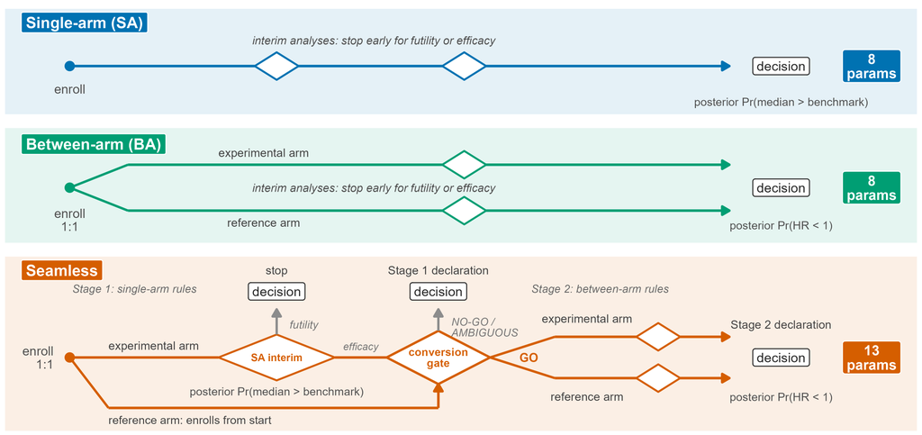

The seamless design starts single-arm and *converts* to a randomized trial mid-stream if an interim gate passes: screen cheaply, then demand randomized evidence from promising cohorts. Thirteen coupled parameters: past what hand calibration can navigate at all.

## In the seamless design, two philosophies collapse into one

Two philosophies not yet shown appear here: **H1-Optimal** (fewest patients when the drug works) and **Balanced** (weights enrollment under both truths equally).

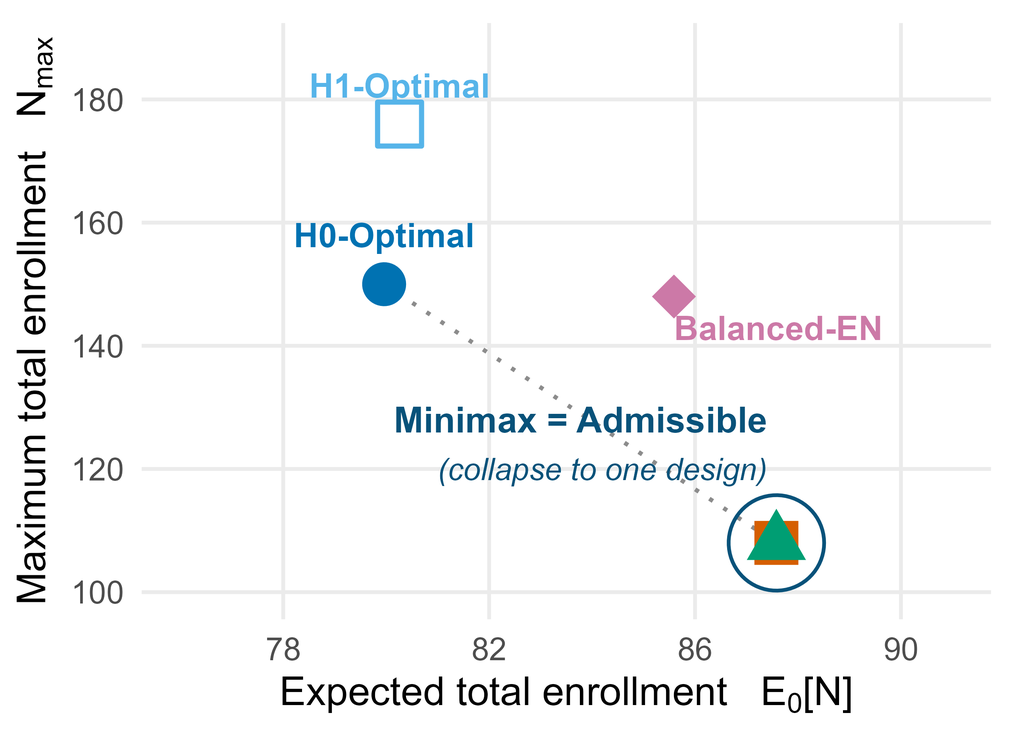

Minimax and Admissible calibrate to the **identical 13-parameter design**: not nearby designs, the same point. No manual search would ever notice this, because no manual search sees the frontier.

## The collapse has a mechanism: the conversion gate

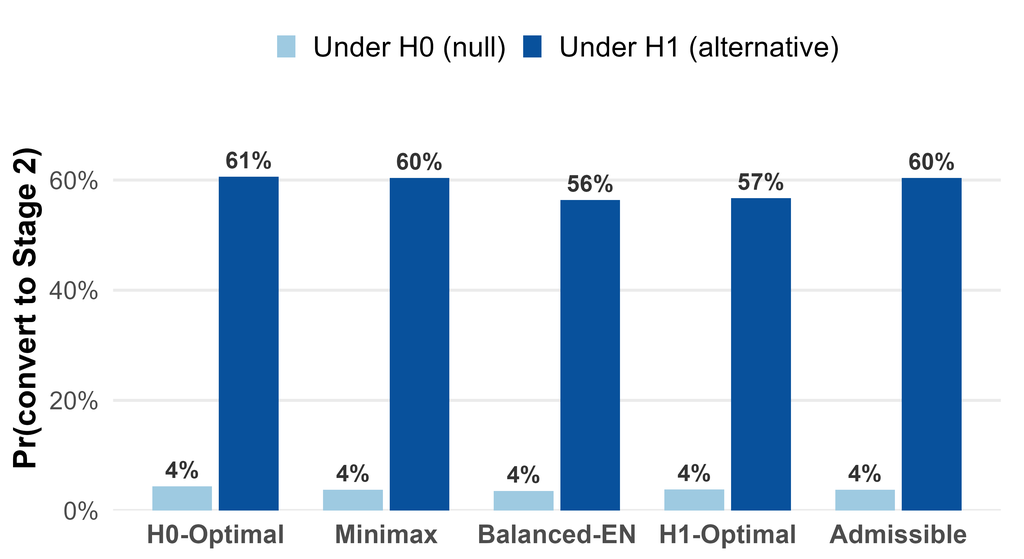

Three steps: **(1)** when the drug fails, only ~4% of trials pass the gate into the randomized stage (versus ~60% when it works); **(2)** so average enrollment under failure is almost entirely stage one; **(3)** the compromise objective goes numb to stage two and lands on the same design Minimax picks.

## Sanity check: on a solved problem, BATON agrees with the solution

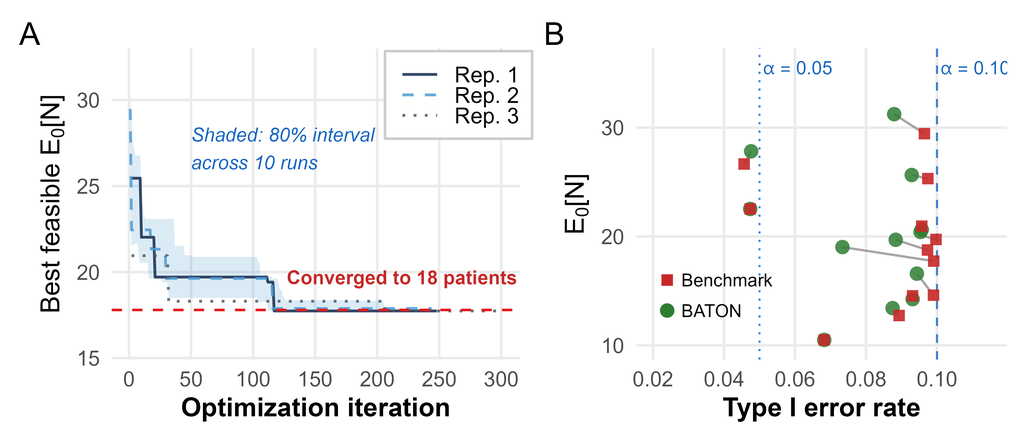

The same known-answer unit test, now across **12 different benchmark scenarios** (one calibration each; the 8-of-10 figure earlier was ten repeats of one scenario). A feasible design in all 12; average sample size within **2.5%** of the Simon optimum at the median, 13.5% at the worst; the exact Simon design in 4.

## Ten seeds, one design

The whole pipeline, rerun end to end at ten independent random seeds:

| Runs returning a feasible design | **10 / 10** |
| --- | --- |
| Runs returning Simon’s exact optimal design | **8 / 10** |
| Expected null enrollment, mean (spread) | **17.77** (0.06) |
| Evaluations used, median | 250 of a 300 budget |

The other two seeds return a near-neighbor design (capacity 29 instead of 25) whose expected enrollment differs by 0.15 patients. What reproduces is the design’s behavior, and usually the design itself.

For a method meant to sit inside regulatory submissions, this is not a nicety. It is what regulatory credibility requires.

Part 4

What it changed

Did this decide anything real?

## Calibration outputs drove four operational decisions in the platform

**1 · Lock contracted capacity**  
Maximum enrollment is capacity locked **~3 months before first enrollment**; frontier curves let the steering committee weigh budget certainty against patient exposure.

**3 · Plan sequential cohorts**  
Per-cohort enrollment and timeline projections flag resource conflicts across the platform’s **10 to 15 sequential subtrials**.

**2 · Align interim data locks**  
Calibrated event gates and interim spacing set the analysis data-lock windows; the platform’s safety board (DSMB) reviews share those locks, the first **within year one**.

**4 · Cut turnaround**  
One illustrative case: two weeks of manual tuning found **no feasible** TNBC design (power stalled at 0.78). BATON, same simulator and constraints, found one at power 0.86 in **under 45 minutes**.

Box 4 is one case, honestly labeled, and still the one to remember: the manual search ran out of time before finding *feasibility*.

## What BATON is, in one slide

1. **A problem formulation**: adaptive-trial calibration as *constrained* optimization over a noisy, expensive simulator, with the feasible frontier as the deliverable.
2. **A working method**: an uncertainty-aware emulator, intelligent selection of the next design to simulate, a cheap-to-expensive simulation ladder, and independent verification of whatever design is reported.
3. **A vocabulary**: design philosophies as named, searchable points on the frontier, so the choice among calibrated designs is made deliberately and on the record.

Open-source R package · manuscript under review at JASA · powering live subtrial designs in an ARPA-H breast cancer platform program

Part 5

Where it goes next

What does calibration look like when the assumptions, the phase, and the pipeline are all in play?

## Three extensions in progress

#### BATON-C

in progress · with Amber Young

**Robustness to assumption uncertainty.** Every calibration so far conditions on one assumed truth. BATON-C optimizes over a *disclosed family* of plausible scenarios, and the family itself becomes part of the record.

#### BATON-D

in progress · working name

**The phase I equivalent.** Phase I trials choose a dose while capping safety risk. Their designs carry tuning parameters set by convention; BATON-D calibrates them, with constraints on overdose risk and correct-dose selection.

#### BATON-D, second paper

scoped

**Scoring early phases by what they set up.** Judge a dose-finding design by the *downstream trials it feeds*: how often they inherit the wrong dose, and what that costs in patients and power.

The through-line: calibration keeps moving upstream: parameters, then assumptions, then the pipeline of trials.

## The larger question: designing early trials to serve later ones

Phase I picks a dose. Phase II inherits it. The confirmatory trial inherits both, plus every interim decision made along the way.

Pick a dose on noisy early data and the confirmatory trial inherits the selection effect: a debt of additional independent evidence it must supply before the final claim is supportable. Today we design each phase for its own metrics, and the debt is invisible until the last trial pays it.

The second BATON-D paper is the concrete first step: measure, in simulation, how early-phase design choices propagate into confirmatory operating characteristics, then calibrate the early phase *against those*.

## The claim, again

Calibrating an adaptive trial does not have one answer. It has a frontier of feasible answers, and nearly every trial picks its point on that frontier without ever seeing the alternatives.

BATON finds the frontier, and puts the choice where it belongs: on the record, with the investigators.

## Acknowledgments

#### ADAPT program

- ARPA-H ADAPT multiple principal investigators
- EVOLVE trial steering committee
- Clinical collaborators across the platform's sites

#### Statistics

- **Amber Young** (UNC), who led BATON's design and validation, and co-leads BATON-C
- **Dinelka Nanayakkara**, ARPA-H statistics group
- ARPA-H ADAPT statistics working group
- Rashid Lab

#### Funding

- ARPA-H 140D042590009
- NCI P50-CA257911 (UNC SToP SPORE)
- DOD HT9425241103100121
- NCI U01-CA274298

Thank you

Questions

naim@unc.edu · rashidlab.github.io

Backup

Reference slides

## Backup: the surrogate and the acquisition

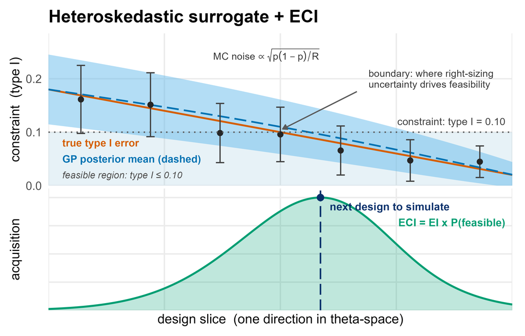

- One GP surrogate per behavior metric (power, type I, expected enrollments).
- **Heteroskedastic** noise model: Monte Carlo variance differs across the space (early-stopping designs give noisier estimates per replication), and hetGP models it rather than assuming it constant.
- Acquisition: **expected constrained improvement**, expected objective gain multiplied by the modeled probability that *every* constraint is satisfied.
- Batched proposals; constraint estimates carry their Monte Carlo standard errors into the model.

## Backup: Simon benchmark, per-scenario

All 12 binary-endpoint benchmark scenarios, BATON vs. the enumerated Simon-optimal design:

[output not shown]

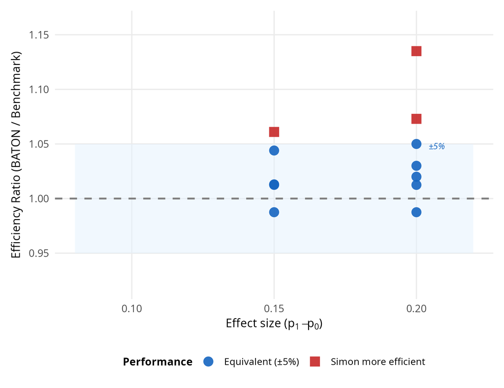

Interpretation: on a discrete design lattice many near-optimal designs sit within Monte Carlo resolution of one another; BATON lands on the optimum or a near-neighbor, and never on an infeasible design.

## Backup: the manual-versus-BATON comparison, in full

**Manual tuning (the TNBC cohort)**  
Two weeks of expert effort produced **no feasible design**. The best manual single-arm point reached power 0.78 at an average null enrollment of 39.2: infeasible on power.

**BATON**  
Found a feasible design (average null enrollment 11.7, power 0.86). Full production workflow about 4 hours wall-clock; a single calibration run under 45 minutes.

An illustrative single comparison (documented in the paper’s web appendix), not a controlled benchmark across analysts. Same simulator, same constraints.

## Backup: what the constraints and parameters actually are

**Calibrated (searched) parameters, single-arm:**

- maximum enrollment; interim spacing; minimum-events gate before decisions count
- posterior futility threshold; posterior efficacy threshold
- decision margin over the historical benchmark
- analysis-prior concentration; hazard-model resolution (piecewise intervals)

Seamless adds conversion-gate thresholds and second-stage sample-size and stopping parameters (13 total).

**Constraints (headline scenarios):**

- type I error at most the ceiling (0.10 in the scenarios shown)
- power at least the floor (0.80)
- seamless designs add gate-behavior constraints (null conversion rate bounded, alternative conversion rate floored)

**Objectives, by philosophy:** expected null enrollment (H0-Optimal), maximum enrollment (Minimax), weighted blends (Admissible family), expected alternative enrollment (H1-Optimal).

Scenario A truths: null median 3.8 months, alternative 9 (hazard ratio 0.42), Weibull shape 1.3, accrual 2 per month; maximum enrollment searched in [30, 120]. Two Simon scenarios use a 0.05 ceiling with 0.90 power.

## Backup: related work and what BATON adds

**Existing approaches**

- **BOP2 / GBOP2** (Zhou; Zhao): grid or particle-swarm search over posterior-probability stopping thresholds; return one design under one criterion.
- **Operating-characteristic acceleration** (Golchi 2022): speeds the estimation, does not optimize the design.
- **Single-objective BO for trial design** (Richter 2022): one objective, without multi-constraint feasibility.
- **gsDesign / rpact / BATSS**: group-sequential and frequentist tooling.

**What BATON adds, jointly in one framework**

1. finds **feasible** designs under **multiple noisy** behavior constraints;
2. models **heteroskedastic** Monte Carlo error;
3. optimizes under **philosophy-specific** sample-size objectives.

It exposes the trade-off surface, and reveals **when philosophies coincide and why**.

## Backup: bidirectional stopping variants

The single-arm and between-arm headline scenarios use futility-only interim stopping (interims can stop for futility; efficacy is decided at the end). The seamless design is calibrated with bidirectional stopping throughout, because its conversion gate is efficacy-driven. The paper’s supplement repeats the single-arm and between-arm calibrations with **bidirectional** stopping, where interims may also stop early for efficacy.

- The frontier structure persists, but the philosophies compress: under bidirectional stopping in Scenario A, H0-Optimal and Admissible calibrate to the same maximum enrollment (31), separating only in thresholds.
- Expected enrollment under the alternative drops substantially (early efficacy stopping pays off exactly when the drug works).
- The choice between stopping structures is itself a design decision upstream of the philosophy choice.